# Univariate Time Series Forecasting - LSTM

#### - Using EarlyStopping() saves us a lot of time, it stops the model training once it realizes that there will be no more decrease in loss in further epochs and training can now be stopped earlier than described epochs.

```python
n_features = 1                        # number of input variables used for forecast (here, only 1 i.e. temperature)

model1 = Sequential()

model1.add(InputLayer((n_input,n_features)))
model1.add(LSTM(100, return_sequences = True))
model1.add(LSTM(100, return_sequences = True))
model1.add(LSTM(50))
model1.add(Dense(8, activation = 'relu'))
model1.add(Dense(1, activation = 'linear'))

model1.summary()
```

```
Model: "sequential_1"
```

```
┏━━━━━━━━━━━━━━━━━━━━━━━━━━━━━━━━━┳━━━━━━━━━━━━━━━━━━━━━━━━┳━━━━━━━━━━━━━━━┓
┃ Layer (type)                    ┃ Output Shape           ┃       Param # ┃
┡━━━━━━━━━━━━━━━━━━━━━━━━━━━━━━━━━╇━━━━━━━━━━━━━━━━━━━━━━━━╇━━━━━━━━━━━━━━━┩
│ lstm_3 (LSTM)                   │ (None, 10, 100)        │        40,800 │
├─────────────────────────────────┼────────────────────────┼───────────────┤
│ lstm_4 (LSTM)                   │ (None, 10, 100)        │        80,400 │
├─────────────────────────────────┼────────────────────────┼───────────────┤
│ lstm_5 (LSTM)                   │ (None, 50)             │        30,200 │
├─────────────────────────────────┼────────────────────────┼───────────────┤
│ dense_2 (Dense)                 │ (None, 8)              │           408 │
├─────────────────────────────────┼────────────────────────┼───────────────┤
│ dense_3 (Dense)                 │ (None, 1)              │             9 │
└─────────────────────────────────┴────────────────────────┴───────────────┘
```

```
 Total params: 151,817 (593.04 KB)
```

```
 Trainable params: 151,817 (593.04 KB)
```

```
 Non-trainable params: 0 (0.00 B)
```

```python
early_stop = EarlyStopping(monitor = 'val_loss', patience = 2)

model1.compile(loss = MeanSquaredError(), optimizer = Adam(learning_rate = 0.0001), metrics = [RootMeanSquaredError()])
```

```python
model1.fit(X_train, y_train, validation_data = (X_val, y_val), epochs = 50, callbacks = [early_stop])
```

```
44/44 ━━━━━━━━━━━━━━━━━━━━ 4s 27ms/step - loss: 24.8806 - root_mean_squared_error: 4.9861 - val_loss: 21.7845 - val_root_mean_squared_error: 4.6674
44/44 ━━━━━━━━━━━━━━━━━━━━ 1s 19ms/step - loss: 21.3390 - root_mean_squared_error: 4.6115 - val_loss: 21.4525 - val_root_mean_squared_error: 4.6317
44/44 ━━━━━━━━━━━━━━━━━━━━ 1s 18ms/step - loss: 15.1454 - root_mean_squared_error: 3.8909 - val_loss: 19.6094 - val_root_mean_squared_error: 4.4283
44/44 ━━━━━━━━━━━━━━━━━━━━ 1s 19ms/step - loss: 14.4014 - root_mean_squared_error: 3.7916 - val_loss: 17.9902 - val_root_mean_squared_error: 4.2415
44/44 ━━━━━━━━━━━━━━━━━━━━ 1s 19ms/step - loss: 12.6511 - root_mean_squared_error: 3.5529 - val_loss: 16.3463 - val_root_mean_squared_error: 4.0431
44/44 ━━━━━━━━━━━━━━━━━━━━ 1s 19ms/step - loss: 9.8758 - root_mean_squared_error: 3.1407 - val_loss: 14.6960 - val_root_mean_squared_error: 3.8335
44/44 ━━━━━━━━━━━━━━━━━━━━ 1s 18ms/step - loss: 9.9697 - root_mean_squared_error: 3.1510 - val_loss: 13.0716 - val_root_mean_squared_error: 3.6155
44/44 ━━━━━━━━━━━━━━━━━━━━ 1s 19ms/step - loss: 9.9664 - root_mean_squared_error: 3.1529 - val_loss: 11.5438 - val_root_mean_squared_error: 3.3976
44/44 ━━━━━━━━━━━━━━━━━━━━ 1s 17ms/step - loss: 7.9739 - root_mean_squared_error: 2.8215 - val_loss: 10.1500 - val_root_mean_squared_error: 3.1859
44/44 ━━━━━━━━━━━━━━━━━━━━ 1s 16ms/step - loss: 6.7168 - root_mean_squared_error: 2.5897 - val_loss: 8.8485 - val_root_mean_squared_error: 2.9746
44/44 ━━━━━━━━━━━━━━━━━━━━ 1s 16ms/step - loss: 7.1367 - root_mean_squared_error: 2.6681 - val_loss: 7.7082 - val_root_mean_squared_error: 2.7764
44/44 ━━━━━━━━━━━━━━━━━━━━ 1s 18ms/step - loss: 6.0740 - root_mean_squared_error: 2.4591 - val_loss: 6.6630 - val_root_mean_squared_error: 2.5813
44/44 ━━━━━━━━━━━━━━━━━━━━ 1s 18ms/step - loss: 5.1940 - root_mean_squared_error: 2.2776 - val_loss: 5.7293 - val_root_mean_squared_error: 2.3936
44/44 ━━━━━━━━━━━━━━━━━━━━ 1s 19ms/step - loss: 4.5803 - root_mean_squared_error: 2.1363 - val_loss: 5.0874 - val_root_mean_squared_error: 2.2555
44/44 ━━━━━━━━━━━━━━━━━━━━ 1s 18ms/step - loss: 3.9593 - root_mean_squared_error: 1.9831 - val_loss: 4.7003 - val_root_mean_squared_error: 2.1680
44/44 ━━━━━━━━━━━━━━━━━━━━ 1s 19ms/step - loss: 3.6481 - root_mean_squared_error: 1.9077 - val_loss: 4.3303 - val_root_mean_squared_error: 2.0809
44/44 ━━━━━━━━━━━━━━━━━━━━ 1s 19ms/step - loss: 3.3045 - root_mean_squared_error: 1.8087 - val_loss: 3.7452 - val_root_mean_squared_error: 1.9352
44/44 ━━━━━━━━━━━━━━━━━━━━ 1s 18ms/step - loss: 2.8549 - root_mean_squared_error: 1.6872 - val_loss: 3.3237 - val_root_mean_squared_error: 1.8231
44/44 ━━━━━━━━━━━━━━━━━━━━ 1s 19ms/step - loss: 2.7641 - root_mean_squared_error: 1.6605 - val_loss: 3.1887 - val_root_mean_squared_error: 1.7857
44/44 ━━━━━━━━━━━━━━━━━━━━ 1s 18ms/step - loss: 2.2953 - root_mean_squared_error: 1.5139 - val_loss: 2.8315 - val_root_mean_squared_error: 1.6827
44/44 ━━━━━━━━━━━━━━━━━━━━ 1s 17ms/step - loss: 2.2647 - root_mean_squared_error: 1.5007 - val_loss: 2.5252 - val_root_mean_squared_error: 1.5891
44/44 ━━━━━━━━━━━━━━━━━━━━ 1s 18ms/step - loss: 1.7428 - root_mean_squared_error: 1.3153 - val_loss: 2.3266 - val_root_mean_squared_error: 1.5253
44/44 ━━━━━━━━━━━━━━━━━━━━ 1s 18ms/step - loss: 2.0024 - root_mean_squared_error: 1.4122 - val_loss: 2.2164 - val_root_mean_squared_error: 1.4888
44/44 ━━━━━━━━━━━━━━━━━━━━ 1s 20ms/step - loss: 1.7238 - root_mean_squared_error: 1.3086 - val_loss: 2.0680 - val_root_mean_squared_error: 1.4381
44/44 ━━━━━━━━━━━━━━━━━━━━ 1s 18ms/step - loss: 1.4351 - root_mean_squared_error: 1.1924 - val_loss: 1.8975 - val_root_mean_squared_error: 1.3775
44/44 ━━━━━━━━━━━━━━━━━━━━ 1s 16ms/step - loss: 1.4350 - root_mean_squared_error: 1.1969 - val_loss: 1.8612 - val_root_mean_squared_error: 1.3643
44/44 ━━━━━━━━━━━━━━━━━━━━ 1s 16ms/step - loss: 1.1682 - root_mean_squared_error: 1.0780 - val_loss: 1.7018 - val_root_mean_squared_error: 1.3045
44/44 ━━━━━━━━━━━━━━━━━━━━ 1s 19ms/step - loss: 1.1457 - root_mean_squared_error: 1.0632 - val_loss: 1.6365 - val_root_mean_squared_error: 1.2792
44/44 ━━━━━━━━━━━━━━━━━━━━ 1s 17ms/step - loss: 1.0298 - root_mean_squared_error: 1.0124 - val_loss: 1.5818 - val_root_mean_squared_error: 1.2577
44/44 ━━━━━━━━━━━━━━━━━━━━ 1s 19ms/step - loss: 1.2235 - root_mean_squared_error: 1.1050 - val_loss: 1.4939 - val_root_mean_squared_error: 1.2223
44/44 ━━━━━━━━━━━━━━━━━━━━ 1s 22ms/step - loss: 1.1064 - root_mean_squared_error: 1.0501 - val_loss: 1.4788 - val_root_mean_squared_error: 1.2161
44/44 ━━━━━━━━━━━━━━━━━━━━ 1s 20ms/step - loss: 1.0428 - root_mean_squared_error: 1.0193 - val_loss: 1.3939 - val_root_mean_squared_error: 1.1806
44/44 ━━━━━━━━━━━━━━━━━━━━ 1s 20ms/step - loss: 0.8383 - root_mean_squared_error: 0.9116 - val_loss: 1.3490 - val_root_mean_squared_error: 1.1615
```

[output cut: 17 more lines]

```
<keras.src.callbacks.history.History at 0x7f3e9c8732f0>
```

```python
losses_df1 = pd.DataFrame(model1.history.history)
losses_df1
```

|  | loss | root_mean_squared_error | val_loss | val_root_mean_squared_error |
| --- | --- | --- | --- | --- |
| 0 | 24.628380 | 4.962699 | 21.784519 | 4.667389 |
| 1 | 18.588568 | 4.311446 | 21.452543 | 4.631689 |
| 2 | 14.957791 | 3.867530 | 19.609428 | 4.428253 |
| 3 | 12.920302 | 3.594482 | 17.990154 | 4.241480 |
| 4 | 11.451184 | 3.383960 | 16.346304 | 4.043056 |
| 5 | 10.337765 | 3.215240 | 14.696033 | 3.833540 |
| 6 | 9.376705 | 3.062140 | 13.071586 | 3.615465 |
| 7 | 8.674920 | 2.945322 | 11.543845 | 3.397623 |
| 8 | 7.790394 | 2.791128 | 10.150002 | 3.185907 |
| 9 | 7.025582 | 2.650581 | 8.848455 | 2.974635 |
| 10 | 6.325982 | 2.515150 | 7.708161 | 2.776357 |
| 11 | 5.695302 | 2.386483 | 6.662981 | 2.581275 |
| 12 | 5.084614 | 2.254909 | 5.729299 | 2.393595 |
| 13 | 4.565358 | 2.136670 | 5.087408 | 2.255528 |
| 14 | 4.082857 | 2.020608 | 4.700263 | 2.168009 |
| 15 | 3.588792 | 1.894411 | 4.330258 | 2.080927 |
| 16 | 3.142581 | 1.772733 | 3.745154 | 1.935240 |
| 17 | 2.866001 | 1.692927 | 3.323720 | 1.823107 |
| 18 | 2.559401 | 1.599813 | 3.188696 | 1.785692 |
| 19 | 2.300238 | 1.516653 | 2.831483 | 1.682701 |
| 20 | 2.133423 | 1.460624 | 2.525233 | 1.589098 |
| 21 | 1.963432 | 1.401225 | 2.326642 | 1.525333 |
| 22 | 1.814533 | 1.347046 | 2.216381 | 1.488752 |
| 23 | 1.689222 | 1.299701 | 2.068010 | 1.438058 |
| 24 | 1.567480 | 1.251990 | 1.897478 | 1.377490 |
| 25 | 1.467347 | 1.211341 | 1.861249 | 1.364276 |
| 26 | 1.384930 | 1.176831 | 1.701787 | 1.304526 |
| 27 | 1.289312 | 1.135479 | 1.636472 | 1.279247 |
| 28 | 1.232814 | 1.110321 | 1.581781 | 1.257689 |
| 29 | 1.169441 | 1.081407 | 1.493948 | 1.222271 |
| 30 | 1.121472 | 1.058996 | 1.478835 | 1.216074 |
| 31 | 1.047228 | 1.023342 | 1.393917 | 1.180643 |
| 32 | 1.007133 | 1.003560 | 1.348973 | 1.161453 |
| 33 | 0.948816 | 0.974072 | 1.281386 | 1.131983 |
| 34 | 0.910220 | 0.954054 | 1.276605 | 1.129869 |
| 35 | 0.882432 | 0.939378 | 1.198863 | 1.094926 |
| 36 | 0.850095 | 0.922006 | 1.200736 | 1.095781 |
| 37 | 0.824526 | 0.908034 | 1.131641 | 1.063786 |
| 38 | 0.798357 | 0.893508 | 1.084085 | 1.041194 |
| 39 | 0.786497 | 0.886846 | 1.061979 | 1.030524 |
| 40 | 0.766042 | 0.875238 | 1.061821 | 1.030447 |
| 41 | 0.739762 | 0.860094 | 1.047317 | 1.023385 |
| 42 | 0.698536 | 0.835784 | 1.014972 | 1.007458 |
| 43 | 0.688300 | 0.829638 | 0.974159 | 0.986995 |
| 44 | 0.663617 | 0.814627 | 0.985697 | 0.992823 |
| 45 | 0.650920 | 0.806796 | 0.950147 | 0.974755 |
| 46 | 0.634171 | 0.796349 | 0.935350 | 0.967135 |
| 47 | 0.643460 | 0.802159 | 0.926520 | 0.962559 |
| 48 | 0.613500 | 0.783262 | 1.001103 | 1.000551 |
| 49 | 0.601065 | 0.775284 | 0.906057 | 0.951870 |

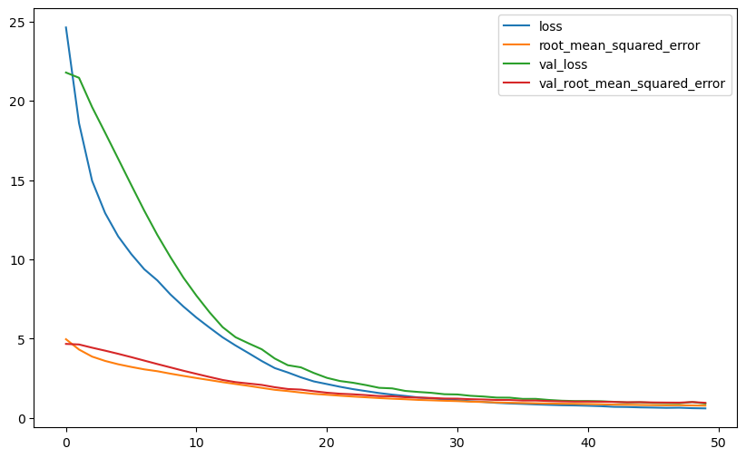

```python
losses_df1.plot(figsize = (10,6))
```

```python
scores = model1.evaluate(X_test, y_test, verbose=0)
print("%s: %.2f%%" % (model1.metrics_names[0], scores[0]*100))
print("%s: %.2f%%" % ('RootMeanSquaredError', scores[1]*100))
```

```
loss: 130.58%
RootMeanSquaredError: 114.27%
```

#### Predict on Test data

```python
test_predictions1 = model1.predict(X_test).flatten()
test_predictions1
```

```
5/5 ━━━━━━━━━━━━━━━━━━━━ 0s 43ms/step
```

```
array([ 3.9522345 ,  3.034131  ,  2.402909  ,  1.8214438 ,  1.9217632 ,
        1.6265886 ,  2.1474392 ,  3.6221645 ,  4.259072  ,  5.0540175 ,
        4.3971524 ,  5.1344013 ,  4.89481   ,  5.676087  ,  5.2256174 ,
        4.433567  ,  3.780132  ,  3.093412  ,  3.5744455 ,  3.6652567 ,
        3.7356517 ,  3.1512685 ,  2.8791668 ,  2.8876646 ,  2.9612782 ,
        2.5964158 ,  2.0195582 ,  2.3547232 ,  2.506327  ,  2.4387455 ,
        2.6074154 ,  3.53125   ,  4.4061627 ,  5.044514  ,  5.1533113 ,
        4.419336  ,  4.894108  ,  5.3499165 ,  5.1011004 ,  4.7270627 ,
        3.7589037 ,  3.1430485 ,  2.9437578 ,  3.0999618 ,  2.7875788 ,
        2.1383913 ,  1.753092  ,  1.5851951 ,  1.2272923 ,  0.16938762,
        0.7645133 ,  1.0958271 ,  0.09855132, -0.24475951,  0.7772189 ,
        3.5916426 ,  3.5688004 ,  5.004644  ,  5.061814  ,  4.932476  ,
        5.296326  ,  4.963943  ,  3.394543  ,  4.4280057 ,  3.1652036 ,
        3.1217868 ,  3.2651646 ,  3.4317062 ,  3.6407402 ,  2.964981  ,
        2.8538778 ,  2.9546645 ,  3.018424  ,  1.9590795 ,  2.1671104 ,
        1.6629233 ,  0.70016986,  0.9986158 ,  1.6063256 ,  1.6558914 ,
        2.7657053 ,  4.437728  ,  5.076122  ,  3.6136556 ,  2.1623833 ,
        1.8235538 ,  2.241336  ,  2.2102537 ,  2.5620813 ,  2.7026055 ,
        3.2051766 ,  4.274972  ,  5.2588625 ,  5.609582  ,  5.6578836 ,
        5.3191667 ,  5.0973845 ,  4.733736  ,  4.246494  ,  4.3403306 ,
        4.0354366 ,  4.3543334 ,  5.120105  ,  5.8689413 ,  6.4377055 ,
        6.61898   ,  6.7262754 ,  6.789699  ,  6.832761  ,  6.8404293 ,
        6.843947  ,  6.8260393 ,  6.66233   ,  6.308283  ,  6.093328  ,
        5.37646   ,  3.6900995 ,  2.3258703 ,  2.5023024 ,  1.2116482 ,
        0.5140031 ,  0.21568017, -0.37885112, -0.6409506 , -0.7782585 ,
       -0.60601014,  0.5656751 ,  2.7600353 ,  4.9706492 ,  5.989953  ,
        6.2748194 ,  6.4361396 ,  6.5514874 ,  6.6552563 ,  6.705197  ,
        6.7647634 ,  6.8000283 ,  6.7404585 ,  6.4267135 ,  6.3299704 ,
        6.222489  ,  6.2439275 ,  6.225808  ,  6.544217  ,  6.509737  ,
        6.2245555 ,  5.826025  ,  5.53978   ,  5.6328835 ,  5.3158026 ,
        5.6116366 ,  5.894636  ,  5.204834  ,  5.665564  ], dtype=float32)
```

```python
len(X_test), len(test_predictions1)
```

```
(154, 154)
```

```python
# check the dimension of the output (should be 1 for time series forecast)

test_predictions1.ndim
```

```
1
```

```python
X_test_list = []
for i in range(len(X_test)):
    X_test_list.append(X_test[i][0])

len(X_test_list)
```

```
154
```

```python
test_predictions_df1 = pd.DataFrame({'X_test':list(X_test_list), 'LSTM Prediction':list(test_predictions1)})
len(test_predictions_df1)
```

```
154
```

```python
test_predictions_df1.head()
```

|  | X_test | LSTM Prediction |
| --- | --- | --- |
| 0 | 5.42 | 3.952235 |
| 1 | 5.17 | 3.034131 |
| 2 | 5.30 | 2.402909 |
| 3 | 5.43 | 1.821444 |
| 4 | 5.11 | 1.921763 |

### LSTM temperature forecast on complete Test Data (6 days)

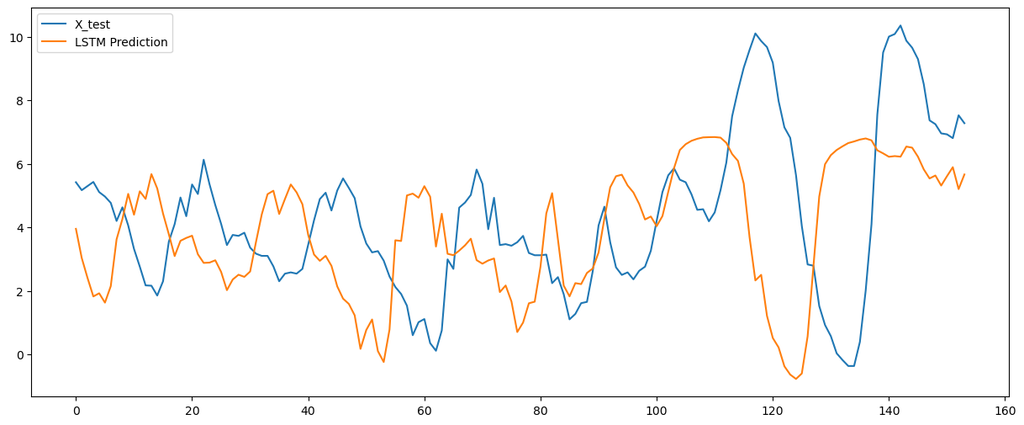

```python
test_predictions_df1.plot(figsize = (15,6))
```